# Activity Data Analysis - Course Project 1

Samarendra Pulicherla

10/27/2017

## Loading and Preprocessing the data

```r
activity <- read.csv(file = "activity.csv", header = TRUE)
str(activity)
```

```
## 'data.frame':    17568 obs. of  3 variables:
##  $ steps   : int  NA NA NA NA NA NA NA NA NA NA ...
##  $ date    : Factor w/ 61 levels "2012-10-01","2012-10-02",..: 1 1 1 1 1 1 1 1 1 1 ...
##  $ interval: int  0 5 10 15 20 25 30 35 40 45 ...
```

```r
library(ggplot2)
library(dplyr)
```

## What is mean total number of steps taken per day

### 1. Make a histogram of the total number of steps taken each day

```r
stepsperday <- aggregate(activity$steps, list(activity$date), sum)
str(stepsperday)
```

```
## 'data.frame':    61 obs. of  2 variables:
##  $ Group.1: Factor w/ 61 levels "2012-10-01","2012-10-02",..: 1 2 3 4 5 6 7 8 9 10 ...
##  $ x      : int  NA 126 11352 12116 13294 15420 11015 NA 12811 9900 ...
```

```r
colnames(stepsperday) <- c("Date","Total_Steps")
head(stepsperday, 10)
```

```
##          Date Total_Steps
## 1  2012-10-01          NA
## 2  2012-10-02         126
## 3  2012-10-03       11352
## 4  2012-10-04       12116
## 5  2012-10-05       13294
## 6  2012-10-06       15420
## 7  2012-10-07       11015
## 8  2012-10-08          NA
## 9  2012-10-09       12811
## 10 2012-10-10        9900
```

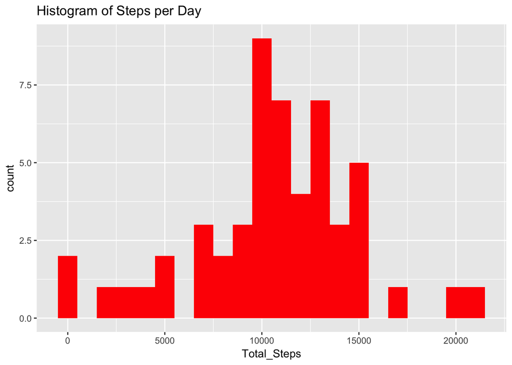

```r
hist_stepsperday <- ggplot(stepsperday, aes(Total_Steps)) +
                    geom_histogram(fill = "red", binwidth = 1000) +
                    ggtitle("Histogram of Steps per Day")
hist_stepsperday
```

### 2. Calculate and report the mean and median total number of steps taken per day

```r
mean_stepsperday <- mean(stepsperday$Total_Steps, na.rm = TRUE)
mean_stepsperday
```

```
## [1] 10766.19
```

```r
median_stepsperday <- median(stepsperday$Total_Steps, na.rm = TRUE)
median_stepsperday
```

```
## [1] 10765
```

## What is the average daily activity pattern

### 1. Make a time series plot (i.e. type = “l”) of the 5-minute interval (x-axis) and the average number of steps taken, averaged across all days (y-axis)

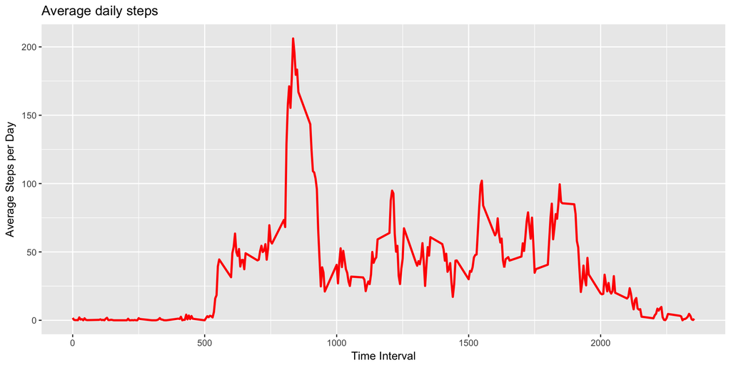

```r
stepspertime <- aggregate(steps ~ interval, data = activity, mean, na.action = na.omit)
plot_stepsperinterval <- ggplot(stepspertime, aes(interval,steps)) +
                         geom_line(color = "red", size = 1) +
                         ggtitle("Average daily steps") +
                         xlab("Time Interval") + ylab("Average Steps per Day")
plot_stepsperinterval
```

### 2. Which 5-minute interval, on average across all the days in the dataset, contains the maximum number of steps?

```r
stepspertime %>% select(interval, steps) %>% filter(steps == max(stepspertime$steps))
```

```
##   interval    steps
## 1      835 206.1698
```

## Imputing Missing values

### 1. Calculate and report the total number of missing values in the dataset (i.e. the total number of rows with NAs)

```r
na_total <- sum(is.na(activity$steps))
na_total
```

```
## [1] 2304
```

### 2. Devise a strategy for filling in all of the missing values in the dataset. The strategy does not need to be sophisticated. For example, you could use the mean/median for that day, or the mean for that 5-minute interval, etc.

```r
# We will fill the missing values using the mean
stepsperinterval <- tapply(activity$steps, activity$interval, mean, na.rm = TRUE)
activity_split <- split(activity, activity$interval)
for(i in 1:length(activity_split)){
  activity_split[[i]]$steps[is.na(activity_split[[i]]$steps)] <- stepsperinterval[i]
}
```

### 3. Create a new dataset that is equal to the original dataset but with the missing data filled in.

```r
activity_imputed <- do.call("rbind", activity_split)
activity_imputed <- activity_imputed[order(activity_imputed$date) ,]
str(activity_imputed)
```

```
## 'data.frame':    17568 obs. of  3 variables:
##  $ steps   : num  1.717 0.3396 0.1321 0.1509 0.0755 ...
##  $ date    : Factor w/ 61 levels "2012-10-01","2012-10-02",..: 1 1 1 1 1 1 1 1 1 1 ...
##  $ interval: int  0 5 10 15 20 25 30 35 40 45 ...
```

### 4. Make a histogram of the total number of steps taken each day and Calculate and report the mean and median total number of steps taken per day. Do these values differ from the estimates from the first part of the assignment? What is the impact of imputing missing data on the estimates of the total daily number of steps?

```r
stepsperday_new <- aggregate(activity_imputed$steps, list(activity_imputed$date), sum)
str(stepsperday_new)
```

```
## 'data.frame':    61 obs. of  2 variables:
##  $ Group.1: Factor w/ 61 levels "2012-10-01","2012-10-02",..: 1 2 3 4 5 6 7 8 9 10 ...
##  $ x      : num  10766 126 11352 12116 13294 ...
```

```r
colnames(stepsperday_new) <- c("Date","Total_Steps")
head(stepsperday_new, 10)
```

```
##          Date Total_Steps
## 1  2012-10-01    10766.19
## 2  2012-10-02      126.00
## 3  2012-10-03    11352.00
## 4  2012-10-04    12116.00
## 5  2012-10-05    13294.00
## 6  2012-10-06    15420.00
## 7  2012-10-07    11015.00
## 8  2012-10-08    10766.19
## 9  2012-10-09    12811.00
## 10 2012-10-10     9900.00
```

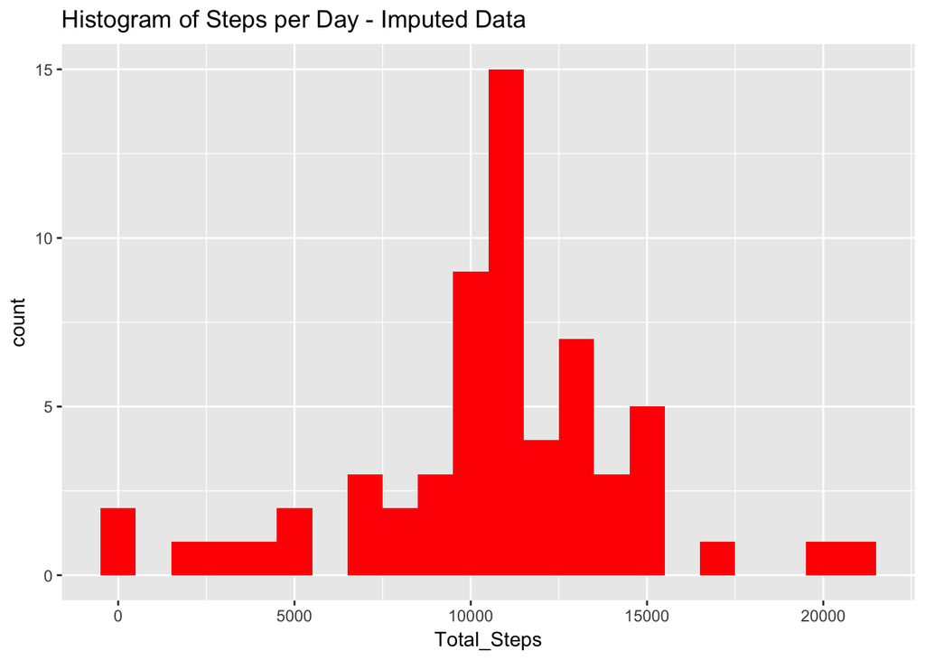

```r
hist_stepsperday_new <- ggplot(stepsperday_new, aes(Total_Steps)) +
                        geom_histogram(fill = "red", binwidth = 1000) +
                        ggtitle("Histogram of Steps per Day - Imputed Data")
hist_stepsperday_new
```

```r
mean_stepsperday_new <- mean(stepsperday_new$Total_Steps, na.rm = TRUE)
mean_stepsperday_new
```

```
## [1] 10766.19
```

```r
median_stepsperday_new <- median(stepsperday_new$Total_Steps, na.rm = TRUE)
median_stepsperday_new
```

```
## [1] 10766.19
```

## Are there differences in activity patterns between weekdays and weekends

### 1. Create a new factor variable in the dataset with two levels – “weekday” and “weekend” indicating whether a given date is a weekday or weekend day

```r
activity_imputed$day <- ifelse(weekdays(as.Date(activity_imputed$date)) == "Saturday" | weekdays(as.Date(activity_imputed$date)) == "Sunday", "weekend", "weekday")
activity_imputed$day <- factor(unlist(activity_imputed$day))
str(activity_imputed)
```

```
## 'data.frame':    17568 obs. of  4 variables:
##  $ steps   : num  1.717 0.3396 0.1321 0.1509 0.0755 ...
##  $ date    : Factor w/ 61 levels "2012-10-01","2012-10-02",..: 1 1 1 1 1 1 1 1 1 1 ...
##  $ interval: int  0 5 10 15 20 25 30 35 40 45 ...
##  $ day     : Factor w/ 2 levels "weekday","weekend": 1 1 1 1 1 1 1 1 1 1 ...
```

### 2. Make a panel plot containing a time series plot (i.e. type = “l”) of the 5-minute interval (x-axis) and the average number of steps taken, averaged across all weekday days or weekend days (y-axis)

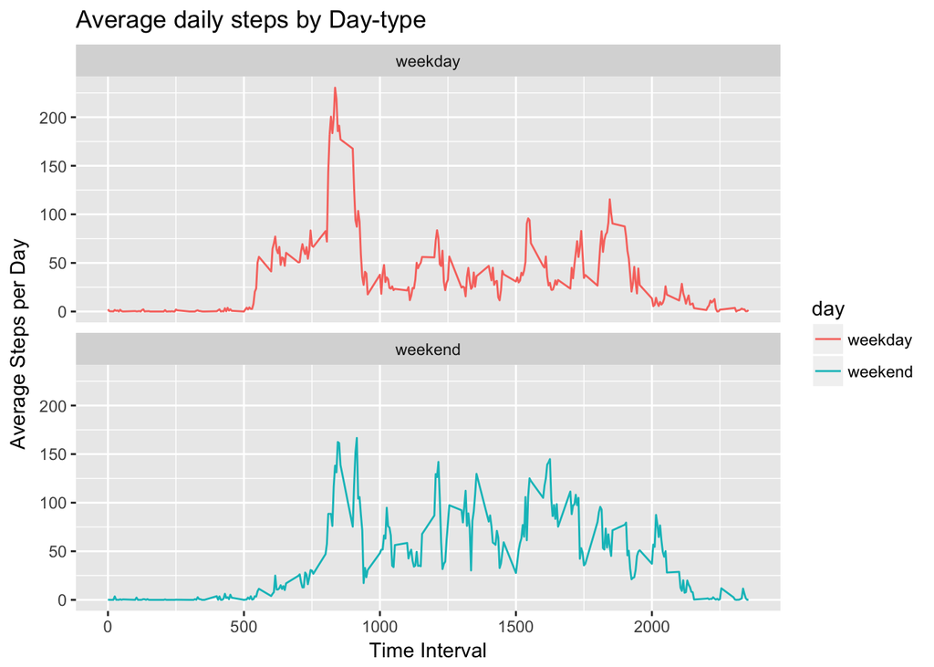

```r
stepspertime_new <- aggregate(steps ~ interval + day, data = activity_imputed, FUN = mean, na.action = na.omit)
plot_stepsperinterval_new <- ggplot(stepspertime_new, aes(interval,steps, color = `day`)) +
                              geom_line() + ggtitle("Average daily steps by Day-type") +
                              xlab("Time Interval") + ylab("Average Steps per Day") +
                              facet_wrap(~`day`, ncol = 1, nrow = 2)
plot_stepsperinterval_new
```